# Homework 10: Random Forests

STAT 432 · Python analysis

## Question 1: Bias–variance trade-off

### (a) Simulation design and estimates

I used NumPy’s `SeedSequence(43210)` to create separate random-number streams for the fixed test predictors, the training data, and the forest seeds. There are **100 repetitions**, with **200 new training observations per repetition** and **200 test predictor vectors generated once and held fixed**. In every repetition, the same training data and forest seed are used for all nine distinct tuning settings. The common `(node size=10, mtry=3)` setting appears in both comparisons and is fitted once per repetition.

The predictors follow $N_5(0,\Sigma)$, with $\Sigma_{jj}=1$ and $\Sigma_{jk}=0.3$ for $j\ne k$. Each training response is $Y=X_1+X_3+X_5+\varepsilon$, where $\varepsilon\sim N(0,1)$ independently. Every fitted `RLT_reg` forest has **500 trees**, with **200 draws with replacement per tree** (`resample_prob=1`, `resample_replace=True`). Reinforcement is off. The other modeling parameters remain at their defaults, including axis-aligned splits, `nsplit=0` (best split), and `alpha=0`. Four threads are used for computation.

RLT’s `min_samples_leaf` is the assignment’s **node-size stopping threshold**: a node with at most that many observations stops splitting. It does not impose that many observations in both daughter nodes. This distinction matters when interpreting the tuning values.

Let $\widehat f_{r,s}(x_j)$ be the prediction in repetition $r$ at test point $j$, for setting $s$, and let

$$\overline f_s(x_j)=\frac{1}{100}\sum_{r=1}^{100}\widehat f_{r,s}(x_j),
\qquad f(x_j)=x_{j1}+x_{j3}+x_{j5}.$$

I computed the squared bias and variance separately at every test point, then averaged:

$$\widehat{B_s^2}=\frac{1}{200}\sum_{j=1}^{200}
\left[\overline f_s(x_j)-f(x_j)\right]^2,$$

$$\widehat V_s=\frac{1}{200}\sum_{j=1}^{200}
\left\{\frac{1}{100}\sum_{r=1}^{100}
\left[\widehat f_{r,s}(x_j)-\overline f_s(x_j)\right]^2\right\}.$$

The variance uses divisor 100, so $\widehat{B_s^2}+\widehat V_s$ equals the empirical MSE against $f(x_j)$ exactly, up to floating-point rounding. The squared-bias estimate is the usual finite-simulation plug-in estimate; it contains Monte Carlo error and has not been corrected for the variability of the simulated mean. Variance includes both training-sample randomness and the randomness of the finite 500-tree forest. No noisy test outcomes are used. The expected prediction MSE for a new response adds the independent noise variance, **1**, to each reported sum.

#### Fix mtry = 3 and vary node size

| Node size | mtry | Squared bias | Variance | Sum / function MSE |
| --- | --- | --- | --- | --- |
| 1 | 3 | 0.1431 | 0.1918 | 0.3349 |
| 5 | 3 | 0.1460 | 0.1862 | 0.3322 |
| 10 | 3 | 0.1592 | 0.1744 | 0.3335 |
| 20 | 3 | 0.2108 | 0.1594 | 0.3702 |
| 30 | 3 | 0.2856 | 0.1557 | 0.4413 |

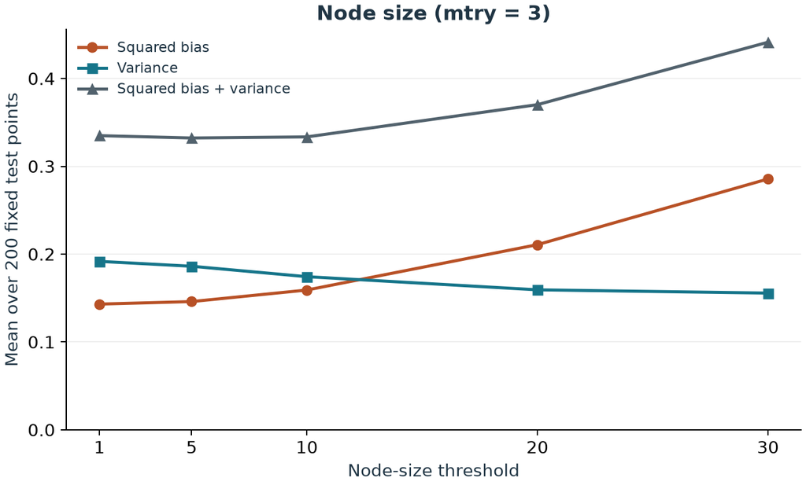

Figure 1: Squared bias, variance, and their sum as the node-size stopping threshold changes. All quantities are averaged over the same 200 test points.

#### Fix node size = 10 and vary mtry

| Node size | mtry | Squared bias | Variance | Sum / function MSE |
| --- | --- | --- | --- | --- |
| 10 | 1 | 0.4870 | 0.1104 | 0.5974 |
| 10 | 2 | 0.2241 | 0.1406 | 0.3648 |
| 10 | 3 | 0.1592 | 0.1744 | 0.3335 |
| 10 | 4 | 0.1407 | 0.1992 | 0.3399 |
| 10 | 5 | 0.1322 | 0.2191 | 0.3513 |

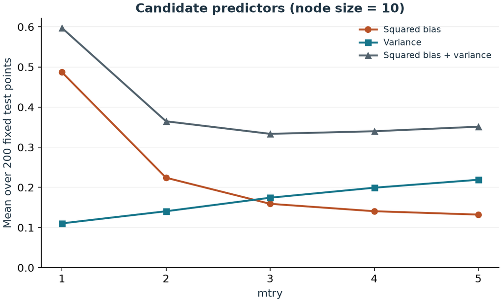

Figure 2: Squared bias, variance, and their sum as mtry changes, with node size fixed at 10.

### (b) Interpretation

**Large node size.** Increasing the threshold from 1 to 30 raises estimated squared bias from **0.1431 to 0.2856**, while reducing variance from **0.1918 to 0.1557**. The coarser partitions average observations across wider predictor regions, which weakens the fit to the changing linear mean. The reduction in variance does not compensate for the increased bias: function MSE rises from **0.3349 to 0.4413**. Thus node size 30 underfits relative to the smaller thresholds in this example. Threshold 5 has the smallest observed sum, **0.3322**, but values 1, 5, and 10 are close; 100 repetitions do not establish a clear population optimum among them.

**Large mtry.** At node size 10, raising `mtry` from 1 to 5 reduces squared bias from **0.4870 to 0.1322**, but raises variance from **0.1104 to 0.2191**. A larger candidate set makes directly useful predictors available more often and lets individual trees select stronger splits. Here the probability of offering no directly active predictor is $2/5$ for `mtry=1`, $1/10$ for `mtry=2`, and zero for `mtry` at least 3. The other predictors are correlated with the active predictors, so they can still act as useful proxies.

The drawback is that a larger candidate set makes greedy split choices more similar across trees, reducing the benefit of averaging, and it increases split-search work. In this run, the best balance is `mtry=3`, with function MSE **0.3335**. At `mtry=5`, all predictors compete at each split, giving bagged trees with MSE **0.3513** despite the smaller bias. These variance patterns are empirical results for this data-generating process, rather than universal monotonicity claims.

**If each tree uses 100 bootstrap draws.** I would initially look toward **smaller node-size thresholds**. Keeping a threshold of 30 while halving the bootstrap size makes that threshold a larger fraction of each tree’s sample (30% instead of 15%), encouraging shallower and coarser trees. A smaller threshold can recover some flexibility and reduce this added bias. However, a smaller bootstrap sample also contains less information and can make individual trees noisier, which could favor stronger smoothing. Therefore I would retune the threshold rather than assume the preferred value must fall, or simply halve it. This is an expectation based on the bias–variance mechanisms; no additional 100-draw simulation is claimed.

## Question 2: Tuning MNIST forests

### Data preparation and PCA

I kept digits 1, 6, and 7 from original rows 1–1,000 for training and from rows 1,001–2,000 for the final test set. The data contain no missing entries. The resulting class counts are:

| Digit | Training | Test |
| --- | --- | --- |
| 1 | 116 | 104 |
| 6 | 94 | 106 |
| 7 | 117 | 107 |
| **Total** | **327** | **317** |

PCA is fitted **only to the 327 training observations and their 784 pixel columns**, after centering each pixel by its training mean. I do not scale pixels or whiten components. I use a full SVD and keep the first **20 principal components**, which explain **77.128%** of training pixel variance. Test scores use the same training means and loadings. The `Digit` column never enters PCA.

Every classification forest uses **1,000 trees**, **327 bootstrap draws with replacement per tree**, axis-aligned splits, and reinforcement off. The forest seed is **43211** for every candidate. Class predictions use the largest averaged class probability, and OOB predictions for a training observation use only trees that excluded it. Test labels are not used for tuning, PCA fitting, or importance calculation.

### (a) Default forest

For 20 predictors, the Python `rlt` defaults resolve to **mtry = 10** and **node size = 5**. The fitted default forest makes **14/327 OOB errors**, giving an OOB misclassification rate of

$$14/327=0.042813=\mathbf{4.281\%}.$$

### (b) OOB tuning and permutation importance

Before examining errors, I specified the grid

$$\texttt{mtry}\in\{1,2,4,6,10,15,20\},\qquad
\text{node size}\in\{1,3,5,10,20,30\}.$$

This gives **42 settings**, covering strong feature randomization through bagging and small through comparatively large node thresholds. The table presents the **OOB error percentage**, followed by the **number of misclassified training observations** in parentheses. All denominators are 327. The default forest is reused at `(mtry=10, node size=5)`.

| Node size / mtry | 1 | 2 | 4 | 6 | 10 | 15 | 20 |
| --- | --- | --- | --- | --- | --- | --- | --- |
| 1 | 2.45% (8) | 2.75% (9) | 3.67% (12) | 3.67% (12) | 4.28% (14) | 4.89% (16) | 4.89% (16) |
| 3 | 2.14% (7) | 3.36% (11) | 3.67% (12) | 3.98% (13) | 4.28% (14) | 4.89% (16) | 4.89% (16) |
| 5 | **1.53% (5)** | 3.36% (11) | 3.67% (12) | 3.67% (12) | 4.28% (14) | 4.89% (16) | 4.89% (16) |
| 10 | 2.45% (8) | 3.36% (11) | 3.67% (12) | 3.67% (12) | 4.28% (14) | 4.89% (16) | 5.20% (17) |
| 20 | 1.83% (6) | 3.06% (10) | 3.67% (12) | 3.67% (12) | 4.59% (15) | 4.89% (16) | 5.20% (17) |
| 30 | 2.75% (9) | 3.36% (11) | 3.67% (12) | 3.67% (12) | 4.59% (15) | 4.89% (16) | 5.20% (17) |

The selection rule minimizes the number of OOB mistakes; ties would prefer smaller `mtry`, then larger node size. The unique minimum is **mtry = 1, node size = 5**, with **5/327 = 1.529%** OOB error. Relative to the default forest, this reduces OOB mistakes from 14 to 5, an improvement of **2.752 percentage points**.

Here strong feature randomization performs better than searching many candidate PCs at each split. This is consistent with useful discrimination being available across several components, while greater tree diversity helps averaging. It is not a guarantee that `mtry=1` will be best for another training sample. One OOB mistake corresponds to about **0.306 percentage points**, so close grid entries should not be treated as precise rankings. The minimum OOB error is also a selection statistic and may be optimistic after searching 42 settings.

#### OOB permutation importance for all 20 components

I fitted the selected forest with `importance="permute"`, keeping the same seed and all modeling settings. Its OOB probabilities and error match the selected grid forest. For each tree, RLT measures the baseline misclassification rate on that tree’s OOB observations, permutes one component among those observations, and measures the increase in error. The importance is the mean increase across the 1,000 trees:

$$\operatorname{VI}_k=\frac{1}{1000}\sum_{b=1}^{1000}
\left(\operatorname{err}^{\mathrm{OOB,perm}(k)}_b-
\operatorname{err}^{\mathrm{OOB}}_b\right).$$

These values are **raw error-rate increases**, not impurity importance, normalized shares, or the error increase of the entire aggregated forest. Multiplying by 100 gives percentage points. Negative estimates would be retained if present; none occur in this fit.

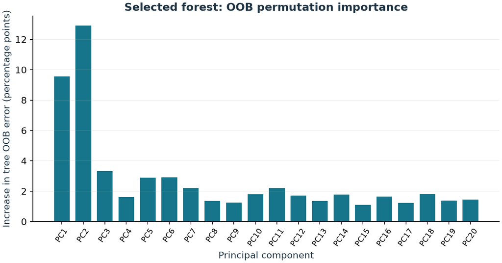

Figure 3: Raw OOB permutation importance for the selected 1,000-tree forest, expressed in percentage points.

| Component | Permutation importance | Increase (percentage points) | Pixel variance (%) |
| --- | --- | --- | --- |
| PC1 | 0.095555 | 9.556 | 18.757 |
| PC2 | 0.129094 | 12.909 | 14.726 |
| PC3 | 0.033286 | 3.329 | 8.429 |
| PC4 | 0.016343 | 1.634 | 5.501 |
| PC5 | 0.028927 | 2.893 | 4.170 |
| PC6 | 0.029169 | 2.917 | 3.572 |
| PC7 | 0.022096 | 2.210 | 2.769 |
| PC8 | 0.013626 | 1.363 | 2.703 |
| PC9 | 0.012533 | 1.253 | 2.237 |
| PC10 | 0.018056 | 1.806 | 1.962 |
| PC11 | 0.022271 | 2.227 | 1.800 |
| PC12 | 0.017166 | 1.717 | 1.662 |
| PC13 | 0.013620 | 1.362 | 1.474 |
| PC14 | 0.017806 | 1.781 | 1.415 |
| PC15 | 0.011076 | 1.108 | 1.207 |
| PC16 | 0.016392 | 1.639 | 1.086 |
| PC17 | 0.012365 | 1.236 | 1.004 |
| PC18 | 0.018145 | 1.814 | 0.924 |
| PC19 | 0.013763 | 1.376 | 0.884 |
| PC20 | 0.014420 | 1.442 | 0.845 |

**Interpretation.** PC2 is most important (**12.909 percentage points**), followed by PC1 (**9.556**) and PC3 (**3.329**). PC6 and PC5 follow at about **2.917** and **2.893** percentage points. The remaining components have smaller but positive measured contributions. PC1 explains more pixel variance than PC2, yet PC2 has greater predictive importance, illustrating that PCA’s variance ranking need not match classification usefulness. Later components can still help classification even when they explain relatively little pixel variance. These are model-dependent importance scores for PC directions, rather than individual pixels, causal effects, or significance tests.

As required, PCA is fitted once using all training pixels before OOB tuning. An OOB observation is excluded from its predicting trees but contributes to the unsupervised PCA basis. Consequently, OOB error evaluates the forests conditional on this training-derived representation; it is not a fully held-out assessment of the entire PCA-plus-forest pipeline. The final test observations contribute to neither the PCA fit nor the forests.

### (c) Final test assessment

After fixing the setting using OOB error, I applied that selected forest to the 317 test observations. It misclassifies **5** observations:

$$\text{Test error}=\frac{5}{317}=0.015773
=\mathbf{1.577\%},\qquad
\text{accuracy}=\mathbf{98.423\%}.$$

Rows in the confusion matrix are actual digits; columns are predicted digits.

| Actual / predicted | 1 | 6 | 7 | Total |
| --- | --- | --- | --- | --- |
| 1 | 102 | 0 | 2 | 104 |
| 6 | 0 | 106 | 0 | 106 |
| 7 | 0 | 3 | 104 | 107 |

Two digit-1 observations are classified as 7, and three digit-7 observations are classified as 6. All 106 digit-6 observations are classified correctly. The test error (**1.577%**) is close to the selected OOB error (**1.529%**), which supports good performance on this particular held-out set. With only five mistakes in a test sample of 317, the result still has sampling uncertainty. I did not compare test errors across candidates or change the model after this assessment.

## Question 3: Planning an analysis skill

### (a) How I would write the skill

I would write a concise skill that states the dataset-specific target, evaluation constraints, required outputs, and my reporting preferences, while leaving routine implementation choices to a capable AI. I would make the essential safeguards explicit, including reproducible seeds, training-only preprocessing, a clearly declared tuning criterion, and an untouched test set, because errors in those steps could invalidate an otherwise polished report. For an AI with limited statistical knowledge, I would add a short ordered workflow, definitions of OOB error and permutation importance, and a small example of the expected output. For a stronger AI, I would avoid a long textbook explanation and emphasize the decisions that depend on my goals. My personal preferences would be brief English interpretations, comparable tuning figures, transparent uncertainty, and a self-contained report with reproducible Python code available in an appendix.

### (b) Ten instructions, from basics to personal preferences

1. **Define the analysis target.** Identify the response, whether the task is regression or classification, eligible predictors, observation unit, and any identifier or leakage columns; check types and missing values before fitting.
2. **Protect evaluation data.** Set and record a seed, define the training and test samples before modeling, and reserve test outcomes for one final assessment after model selection.
3. **Fit preprocessing on training data.** Learn imputation, encoding, scaling, or PCA on training observations and reuse those fitted transformations on evaluation data; refit transformations inside resampling when evaluating the complete pipeline.
4. **State forest settings precisely.** Record the Python package and version, tree count, bootstrap size and replacement rule, reinforcement choice, and the package-specific meanings of `mtry` and node size.
5. **Make tuning reproducible.** Declare a reasonable `mtry`–node-size grid, selection metric, and tie-breaking rule before comparing results, and use the same training sample and comparable randomization across candidates.
6. **Report performance completely.** Show every candidate’s OOB or validation error and the selected setting; report final test MSE for regression or misclassification rate with a labeled confusion matrix for classification.
7. **Use interpretable importance.** Prefer OOB permutation importance over impurity importance, display all predictors including negative scores, state the units, and explain limitations for correlated variables or transformed predictors.
8. **Make comparisons easy to read.** Use compact tables and a small number of clearly labeled figures with consistent scales, identifiable selected settings, and captions that state the data and metric being compared.
9. **Explain the practical result.** Write short paragraphs connecting observed performance to bias, variance, and tree diversity; separate measured findings from expectations and avoid presenting tiny differences as conclusive improvements.
10. **Follow my presentation preferences.** Use plain English, a restrained navy-and-teal style, and a self-contained HTML report; keep the main discussion concise and place runnable Python code, seeds, and environment details in an expandable appendix.

## Reproducibility appendix

The original assignment is preserved locally as `homework-10-template.qmd`. The analysis saves predictions for **9 × 100 × 200** setting–repetition–test-point combinations, pointwise bias and variance, all OOB grid results, all 20 importance values, PCA means and loadings, and final predictions. Assertions verify the bootstrap sizes, tree counts, reinforcement settings, OOB rates, probability sums, and the bias–variance decomposition. The selected parameters are saved before reading the test block for final evaluation.

Python version: **3.12.14**. Analysis seeds: **43210** (simulation) and **43211** (MNIST forests).

| Package | Version |
| --- | --- |
| rlt-forests | 0.2.0 |
| numpy | 2.3.5 |
| pandas | 2.2.3 |
| scipy | 1.18.1 |
| scikit-learn | 1.9.1 |
| matplotlib | 3.11.2 |

Package references: [the course’s random-forest notes](https://teazrq.github.io/stat432rpy/topics/random-forests/random-forests.html) and [the Python RLT source](https://github.com/rqzhu-aide/rlt-python/tree/d24d4333e90315268b75bde26ff08fa452cfaabd). The exact source commit is `d24d4333e90315268b75bde26ff08fa452cfaabd`.

**Implementation detail for this package version.** In the local source’s importance dispatcher, `var_mode="none"` is a truthy string and can redirect `importance="permute"` to distributed importance. The selected model explicitly passes `var_mode=None`, and an assertion checks that the core’s importance code is **1** (permutation) and variance mode is **0**. The statistical fitting core was not modified. On this Mac, build flags were adapted to Apple Clang, local OpenMP, and Accelerate; a compiled wheel and official source archive are retained in `vendor/`.

From `homework/week-10/`, reproduce the analysis and report with:

```bash
.venv/bin/python analyze_homework_10.py --jobs 4
.venv/bin/python render_homework_10.py
quarto render homework-10.qmd --to html
```

The two Python files, result tables, and figures are working materials. The self-contained `homework-10.html` is the submission artifact.

**Complete Python analysis code**

```python
"""Reproduce STAT 432 Homework 10 using the course's Python RLT package.

Run from any directory with this week's .venv/bin/python. Outputs are saved
beside this script; no test outcomes enter model selection.
"""
from __future__ import annotations

import argparse
import hashlib
import importlib.metadata
import json
import os
from pathlib import Path
import platform
import time

HERE = Path(__file__).resolve().parent
os.environ.setdefault("MPLCONFIGDIR", str(HERE / ".mplconfig"))
import matplotlib
matplotlib.use("Agg")
import matplotlib.pyplot as plt
import numpy as np
import pandas as pd
from rlt import RLT_cla, RLT_reg
from sklearn.decomposition import PCA
from sklearn.metrics import confusion_matrix
from threadpoolctl import threadpool_limits

SEED = 43210
MNIST_SEED = 43211
REPETITIONS = 100
NTEST = NTRAIN = 200
# The overlapping (node size=10, mtry=3) setting is fitted only once.
SETTINGS = [(node, 3) for node in [1, 5, 10, 20, 30]] + [
    (10, mtry) for mtry in [1, 2, 4, 5]
]
# Declare the grid and tie-breaking rule before looking at any OOB errors.
MTRY_GRID = [1, 2, 4, 6, 10, 15, 20]
NODE_GRID = [1, 3, 5, 10, 20, 30]
SOURCE_COMMIT = "d24d4333e90315268b75bde26ff08fa452cfaabd"

plt.rcParams.update({
    "font.family": "DejaVu Sans", "font.size": 11,
    "axes.spines.top": False, "axes.spines.right": False,
    "axes.labelcolor": "#203544", "text.color": "#203544",
    "axes.titleweight": "bold", "figure.facecolor": "white",
    "savefig.facecolor": "white",
})


def dump_json(filename, value):
    (HERE / filename).write_text(json.dumps(value, indent=2) + "\n", encoding="utf-8")


def check_forest(model, trees, bootstrap_size):
    p = model.params_
    assert p.ntrees == trees
    assert p.replacement and int(p.n * p.resample_prob) == bootstrap_size
    assert not p.reinforcement and p.linear_comb == 1


def question_1(n_jobs):
    start = time.perf_counter()
    test_ss, train_ss, forest_ss = np.random.SeedSequence(SEED).spawn(3)
    test_rng = np.random.default_rng(test_ss)
    train_rng = np.random.default_rng(train_ss)
    forest_rng = np.random.default_rng(forest_ss)
    covariance = np.full((5, 5), 0.3)
    np.fill_diagonal(covariance, 1.0)
    test_x = test_rng.multivariate_normal(np.zeros(5), covariance, size=NTEST)
    truth = test_x[:, [0, 2, 4]].sum(axis=1)
    predictions = np.empty((len(SETTINGS), REPETITIONS, NTEST))
    train_x = np.empty((REPETITIONS, NTRAIN, 5))
    train_y = np.empty((REPETITIONS, NTRAIN))
    forest_seeds = forest_rng.integers(0, 2**31 - 1, size=REPETITIONS)

    for rep in range(REPETITIONS):
        x = train_rng.multivariate_normal(np.zeros(5), covariance, size=NTRAIN)
        y = x[:, [0, 2, 4]].sum(axis=1) + train_rng.normal(size=NTRAIN)
        train_x[rep], train_y[rep] = x, y
        for k, (node, mtry) in enumerate(SETTINGS):
            model = RLT_reg(
                n_estimators=500, mtry=mtry, min_samples_leaf=node,
                resample_prob=1.0, resample_replace=True,
                reinforcement=False, random_state=int(forest_seeds[rep]),
                n_jobs=n_jobs,
            ).fit(x, y)
            check_forest(model, 500, NTRAIN)
            predictions[k, rep] = model.predict(test_x)
        if (rep + 1) % 10 == 0:
            print(f"Q1: {rep + 1}/{REPETITIONS} repetitions "
                  f"({time.perf_counter() - start:.1f}s)", flush=True)

    means = predictions.mean(axis=1)
    bias_sq = (means - truth) ** 2
    # Divisor R gives the exact empirical bias^2 + variance decomposition.
    variance = predictions.var(axis=1, ddof=0)
    function_mse = ((predictions - truth) ** 2).mean(axis=1)
    assert np.allclose(bias_sq + variance, function_mse, rtol=1e-12, atol=1e-12)
    rows = []
    pointwise = []
    for k, (node, mtry) in enumerate(SETTINGS):
        rows.append({
            "node_size": node, "mtry": mtry,
            "bias_squared": float(bias_sq[k].mean()),
            "variance": float(variance[k].mean()),
            "function_mse": float(function_mse[k].mean()),
            "expected_response_mse": float(function_mse[k].mean() + 1),
        })
        for j in range(NTEST):
            pointwise.append({"node_size": node, "mtry": mtry,
                              "test_point": j + 1, "true_mean": truth[j],
                              "mean_prediction": means[k, j],
                              "bias_squared": bias_sq[k, j],
                              "variance": variance[k, j]})
    table = pd.DataFrame(rows)
    table.to_csv(HERE / "q1_bias_variance.csv", index=False)
    pd.DataFrame(pointwise).to_csv(HERE / "q1_pointwise.csv", index=False)
    np.savez_compressed(
        HERE / "q1_predictions.npz", predictions=predictions,
        settings=np.asarray(SETTINGS), test_x=test_x, true_mean=truth,
        train_x=train_x, train_y=train_y, forest_seeds=forest_seeds,
    )
    for parameter, fixed, name, title in [
        ("node_size", table.mtry.eq(3), "q1_node_size.png", "Node size (mtry = 3)"),
        ("mtry", table.node_size.eq(10), "q1_mtry.png", "Candidate predictors (node size = 10)"),
    ]:
        subset = table.loc[fixed].sort_values(parameter)
        fig, ax = plt.subplots(figsize=(7.3, 4.4), layout="constrained")
        for column, label, color, marker in [
            ("bias_squared", "Squared bias", "#b85126", "o"),
            ("variance", "Variance", "#16758a", "s"),
            ("function_mse", "Squared bias + variance", "#52626d", "^"),
        ]:
            ax.plot(subset[parameter], subset[column], marker=marker,
                    color=color, label=label, linewidth=2)
        ax.set(title=title, xlabel="Node-size threshold" if parameter == "node_size" else "mtry",
               ylabel="Mean over 200 fixed test points")
        ax.set_xticks(subset[parameter])
        ax.set_ylim(bottom=0)
        ax.grid(axis="y", alpha=0.2)
        ax.legend(frameon=False, fontsize=9, loc="best")
        fig.savefig(HERE / name, dpi=180)
        plt.close(fig)
    result = {"seed": SEED, "repetitions": REPETITIONS,
              "n_train": NTRAIN, "n_test": NTEST, "n_trees": 500,
              "settings": rows, "seconds": time.perf_counter() - start}
    dump_json("q1_results.json", result)
    return result
```

```python
def oob_mistakes(model, labels):
    probabilities = model.oob_prob_
    assert np.isfinite(probabilities).all()
    assert np.allclose(probabilities.sum(axis=1), 1)
    prediction = model.classes_[probabilities.argmax(axis=1)]
    errors = int(np.count_nonzero(prediction != labels))
    assert np.isclose(errors / len(labels), model.oob_error_)
    return errors, prediction


def question_2(n_jobs):
    start = time.perf_counter()
    data_path = HERE / "data/mnist-first2000.csv.gz"
    data = pd.read_csv(data_path)
    assert data.shape == (2000, 785) and "Digit" in data.columns
    assert not data.isna().any().any()
    train = data.iloc[:1000]
    train = train.loc[train.Digit.isin([1, 6, 7])]
    x = train.drop(columns="Digit").to_numpy(dtype=float)
    y = train.Digit.to_numpy(dtype=int)
    # PCA centers pixels; no StandardScaler and no whitening are used.
    pca = PCA(n_components=20, svd_solver="full", whiten=False)
    scores = pca.fit_transform(x)
    assert np.allclose(scores, (x - pca.mean_) @ pca.components_.T)
    assert np.allclose(scores.mean(axis=0), 0, atol=1e-10)
    common = dict(n_estimators=1000, resample_prob=1.0,
                  resample_replace=True, reinforcement=False,
                  random_state=MNIST_SEED, n_jobs=n_jobs)
    baseline = RLT_cla(**common).fit(scores, y)
    check_forest(baseline, 1000, len(y))
    base_errors, _ = oob_mistakes(baseline, y)
    assert baseline.params_.mtry == 10 and baseline.params_.nmin == 5

    rows, best_model, best_key = [], None, None
    for mtry in MTRY_GRID:
        for node in NODE_GRID:
            model = baseline if (mtry, node) == (10, 5) else RLT_cla(
                mtry=mtry, min_samples_leaf=node, **common
            ).fit(scores, y)
            check_forest(model, 1000, len(y))
            errors, _ = oob_mistakes(model, y)
            rows.append({"mtry": mtry, "node_size": node,
                         "oob_mistakes": errors, "n_train": len(y),
                         "oob_error": errors / len(y)})
            # Ties: smaller mtry, then larger node size.
            key = (errors, mtry, -node)
            if best_key is None or key < best_key:
                best_model, best_key = model, key
        print(f"Q2: mtry={mtry}, all six node sizes fitted", flush=True)
    grid = pd.DataFrame(rows)
    grid.to_csv(HERE / "q2_oob_grid.csv", index=False)
    selected = {"mtry": int(best_model.params_.mtry),
                "node_size": int(best_model.params_.nmin),
                "oob_mistakes": best_key[0],
                "oob_error": best_key[0] / len(y)}

    # In this package version the string var_mode='none' is truthy in the
    # importance dispatcher. Pass None to request actual permutation (code 1),
    # rather than inadvertently requesting distributed importance (code 2).
    selected_model = RLT_cla(
        mtry=selected["mtry"], min_samples_leaf=selected["node_size"],
        importance="permute", var_mode=None, **common,
    ).fit(scores, y)
    check_forest(selected_model, 1000, len(y))
    assert selected_model.params_.importance == 1
    assert selected_model.params_.var_mode == 0
    selected_errors, oob_prediction = oob_mistakes(selected_model, y)
    assert selected_errors == best_key[0]
    assert np.allclose(selected_model.oob_prob_, best_model.oob_prob_)
    # Importance is the raw mean increase in individual-tree OOB error.
    importance = np.asarray(selected_model.feature_importances_).ravel()
    assert importance.shape == (20,) and np.isfinite(importance).all()
    importance_table = pd.DataFrame({
        "PC": [f"PC{j}" for j in range(1, 21)],
        "permutation_importance": importance,
        "increase_percentage_points": 100 * importance,
        "explained_variance_ratio": pca.explained_variance_ratio_,
    })
    importance_table.to_csv(HERE / "q2_importance.csv", index=False)
    pd.DataFrame({"row_1based": train.index + 1, "true_digit": y,
                  "oob_predicted_digit": oob_prediction}).to_csv(
                      HERE / "q2_oob_predictions.csv", index=False)
    # Freeze the selection before touching the second half or its labels.
    dump_json("q2_selection_before_test.json", selected)
    np.savez_compressed(HERE / "q2_pca.npz", mean=pca.mean_,
                        loadings=pca.components_,
                        explained_variance_ratio=pca.explained_variance_ratio_)

    test = data.iloc[1000:]
    test = test.loc[test.Digit.isin([1, 6, 7])]
    test_scores = pca.transform(test.drop(columns="Digit").to_numpy(dtype=float))
    test_prediction = selected_model.predict(test_scores)
    test_y = test.Digit.to_numpy(dtype=int)
    test_errors = int(np.count_nonzero(test_prediction != test_y))
    matrix = confusion_matrix(test_y, test_prediction, labels=[1, 6, 7])
    assert matrix.sum() == len(test_y) and np.trace(matrix) == len(test_y) - test_errors
    pd.DataFrame(matrix, index=["True 1", "True 6", "True 7"],
                 columns=["Predicted 1", "Predicted 6", "Predicted 7"]).to_csv(
                     HERE / "q2_confusion_matrix.csv")
    pd.DataFrame({"row_1based": test.index + 1, "true_digit": test_y,
                  "predicted_digit": test_prediction}).to_csv(
                      HERE / "q2_test_predictions.csv", index=False)
    fig, ax = plt.subplots(figsize=(8.4, 4.4), layout="constrained")
    colors = ["#16758a" if value >= 0 else "#b85126" for value in importance]
    ax.bar(importance_table.PC, 100 * importance, color=colors, width=0.73)
    ax.axhline(0, color="#52626d", linewidth=0.7)
    ax.set(title="Selected forest: OOB permutation importance",
           xlabel="Principal component", ylabel="Increase in tree OOB error (percentage points)")
    ax.tick_params(axis="x", rotation=55, labelsize=9)
    ax.grid(axis="y", alpha=0.18)
    fig.savefig(HERE / "q2_importance.png", dpi=180)
    plt.close(fig)
    result = {
        "seed": MNIST_SEED, "data_sha256": hashlib.sha256(data_path.read_bytes()).hexdigest(),
        "n_train": len(y), "n_test": len(test_y), "n_pixels": x.shape[1],
        "train_counts": {str(k): int(v) for k, v in train.Digit.value_counts().sort_index().items()},
        "test_counts": {str(k): int(v) for k, v in test.Digit.value_counts().sort_index().items()},
        "pca_variance_retained": float(pca.explained_variance_ratio_.sum()),
        "default": {"mtry": int(baseline.params_.mtry),
                    "node_size": int(baseline.params_.nmin),
                    "oob_mistakes": base_errors, "oob_error": float(baseline.oob_error_)},
        "selected": selected, "grid_size": len(grid),
        "ties_at_minimum": grid.loc[grid.oob_mistakes.eq(best_key[0])].to_dict(orient="records"),
        "importance": importance_table.to_dict(orient="records"),
        "test_mistakes": test_errors, "test_error": test_errors / len(test_y),
        "confusion_matrix": matrix.tolist(), "seconds": time.perf_counter() - start,
    }
    dump_json("q2_results.json", result)
    print(f"Q2 selected {selected}; test {test_errors}/{len(test_y)}", flush=True)
    return result
```

```python
def main():
    parser = argparse.ArgumentParser()
    parser.add_argument("--question", choices=["1", "2", "all"], default="all")
    parser.add_argument("--jobs", type=int, default=4)
    args = parser.parse_args()
    with threadpool_limits(limits=1, user_api="blas"):
        if args.question in ["1", "all"]:
            question_1(args.jobs)
        if args.question in ["2", "all"]:
            question_2(args.jobs)
    metadata = {"python": platform.python_version(), "rlt_source_commit": SOURCE_COMMIT,
                "packages": {name: importlib.metadata.version(name) for name in
                             ["rlt-forests", "numpy", "pandas", "scipy", "scikit-learn", "matplotlib"]},
                "n_jobs": args.jobs}
    dump_json("environment.json", metadata)


if __name__ == "__main__":
    main()
```